# **Interactive Web App**

# (I) Background

- Instructor: Peng Wang, AVP, Head of Data Science - Operation & Fraud Detection at MassMutual Financial Group
- The data set used in this project is *gapminder* from **bioconnector.org**. The data set includes the data of *Life Expectancy*, *Population*, *GDP per Capita* of all the countries of each continent from 1952 to 2007 with an interval of 5 years.
- [Download Data](http://bioconnector.org/data/gapminder.csv)
- Multiple visulizations of the data set (Section II) and an interactive web application (Section III) were made in this project report.

# (II) Visulizations

```r
library(dplyr)
library(readr)
library(stats)
library(knitr)
library(ggplot2)
library(tidyr)
gapminder=read.csv("https://raw.githubusercontent.com/HarryLu95/dalu/master/Project%20Files/gapminder.csv")
colnames(gapminder)=c("Country","Continent","Year","Life.Expectancy","Population","GDP.per.Capita")
```

## 1. How many unique countries are represented per continent?

```r
table.1=gapminder %>%
  group_by(Continent) %>%
  summarise(Country=n_distinct(Country))
kable(table.1,col.names=c("Continent","Country"),align="c")
```

| Continent | Country |
| --- | --- |
| Africa | 52 |
| Americas | 25 |
| Asia | 33 |
| Europe | 30 |
| Oceania | 2 |

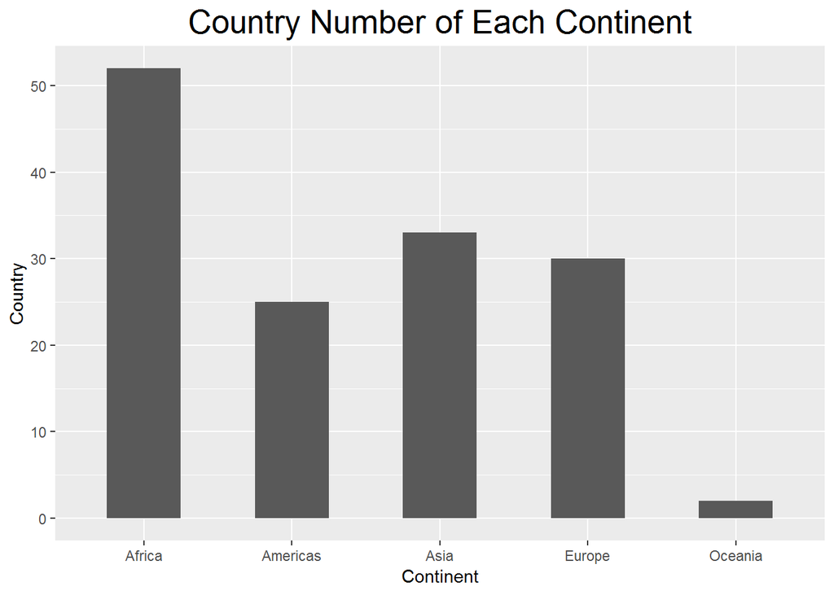

```r
ggplot(data=table.1)+
  geom_col(mapping=aes(Continent,Country),width=0.5)+
  ggtitle("Country Number of Each Continent")+
  xlab("Continent")+
  ylab("Country")+
  theme(plot.title=element_text(size=20,hjust=0.5))
```

## 2. According to the data available, what was the average *Life Expectancy* across each continent from 1952 to 2007?

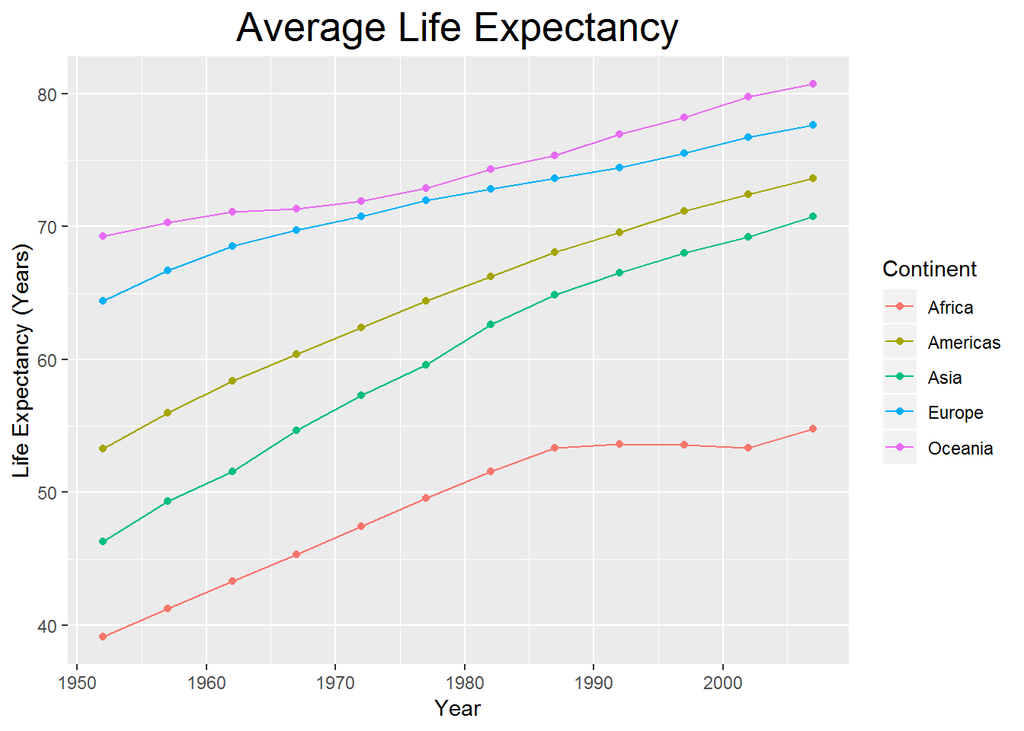

```r
le=tapply(gapminder$Life.Expectancy,list(gapminder$Continent,gapminder$Year),mean)
le=data.frame(t(le))
Year=seq(from=1952,to=2007,by=5)
le=cbind(Year,le)
le=gather(data=le,Continent,Average.Life.Expectancy,-Year)
p1=ggplot(data=le,aes(x=Year,y=Average.Life.Expectancy,color=Continent))+
  geom_point()+
  geom_line()+
  ggtitle("Average Life Expectancy")+
  xlab("Year")+
  ylab("Life Expectancy (Years)")+
  theme(plot.title=element_text(size=20,hjust=0.5))
p1
```

### 2.1 Life Expectancy for Every Countries in Americas

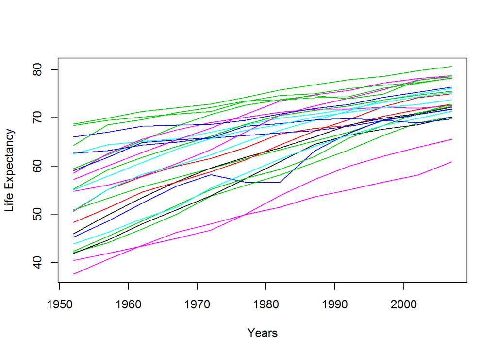

```r
le.Americas=gapminder%>%filter(Continent=="Americas")
le.Americas=tapply(le.Americas$Life.Expectancy,list(le.Americas$Country,le.Americas$Year),mean)
le.Americas=t(data.frame(le.Americas))
row.names(le.Americas)=seq(1952,2007,5)
matplot(seq(1952,2007,5),le.Americas,type="l",lty=1,xlab="Years",ylab="Life Expectancy")
```

### 2.2 Countries that have the **longest** average Life Expectancy in the world

```r
lle=sort(tapply(gapminder$Life.Expectancy,gapminder$Country,mean),decreasing=TRUE)[1:5]
lle=as.data.frame(lle)
colnames(lle)="Average Life Expectancy"
kable(lle,align="c")
```

|  | Average Life Expectancy |
| --- | --- |
| Iceland | 76.51142 |
| Sweden | 76.17700 |
| Norway | 75.84300 |
| Netherlands | 75.64850 |
| Switzerland | 75.56508 |

### 2.3 Countries that have the **shortest** average Life Expectancy in the world

```r
sle=sort(tapply(gapminder$Life.Expectancy,gapminder$Country,mean),decreasing=FALSE)[1:5]
sle=as.data.frame(sle)
colnames(sle)="Average Life Expectancy"
kable(sle,align="c")
```

|  | Average Life Expectancy |
| --- | --- |
| Sierra Leone | 36.76917 |
| Afghanistan | 37.47883 |
| Angola | 37.88350 |
| Guinea-Bissau | 39.21025 |
| Mozambique | 40.37950 |

## 3. According to the data available, what was the average *Population* across each continent from 1952 to 2007?

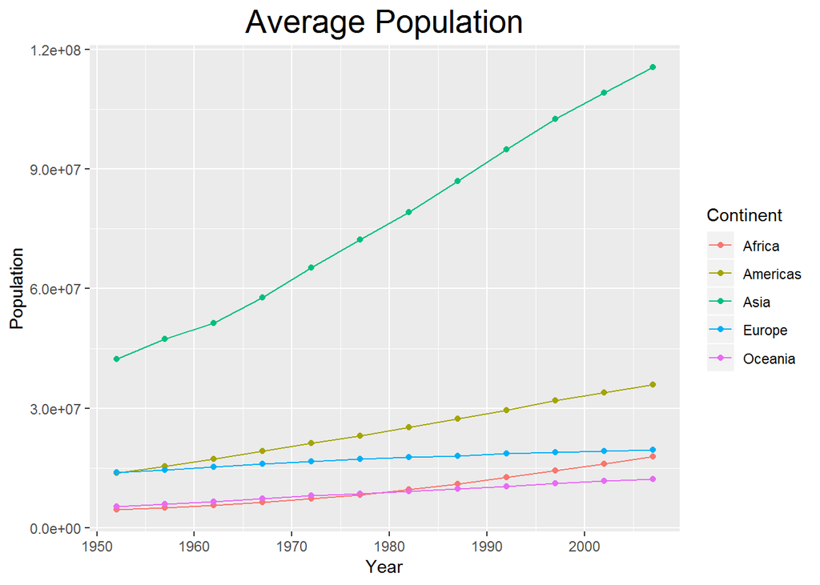

```r
pop=tapply(gapminder$Population,list(gapminder$Continent,gapminder$Year),mean)
pop=data.frame(t(pop))
Year=seq(from=1952,to=2007,by=5)
pop=cbind(Year,pop)
pop=gather(data=pop,Continent,Population,-Year)
p2=ggplot(data=pop,aes(x=Year,y=Population,color=Continent))+
  geom_point()+
  geom_line()+
  ggtitle("Average Population")+
  xlab("Year")+
  ylab("Population")+
  theme(plot.title=element_text(size=20,hjust=0.5))
p2
```

### 3.1 Population for Every Countries in Americas

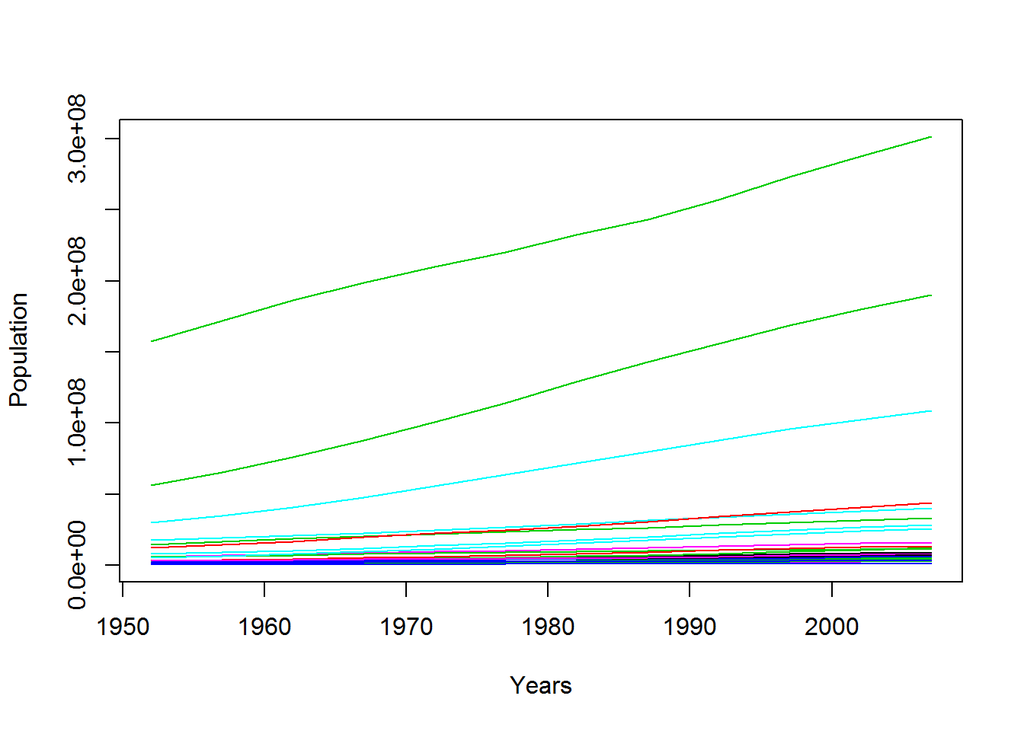

```r
pop.Americas=gapminder%>%filter(Continent=="Americas")
pop.Americas=tapply(pop.Americas$Population,list(pop.Americas$Country,pop.Americas$Year),mean)
pop.Americas=t(data.frame(pop.Americas))
row.names(pop.Americas)=seq(1952,2007,5)
matplot(seq(1952,2007,5),pop.Americas,type="l",lty=1,xlab="Years",ylab="Population")
```

## 4. According to the data available, what was the average *GDP per Capita* across each continent from 1952 to 2007?

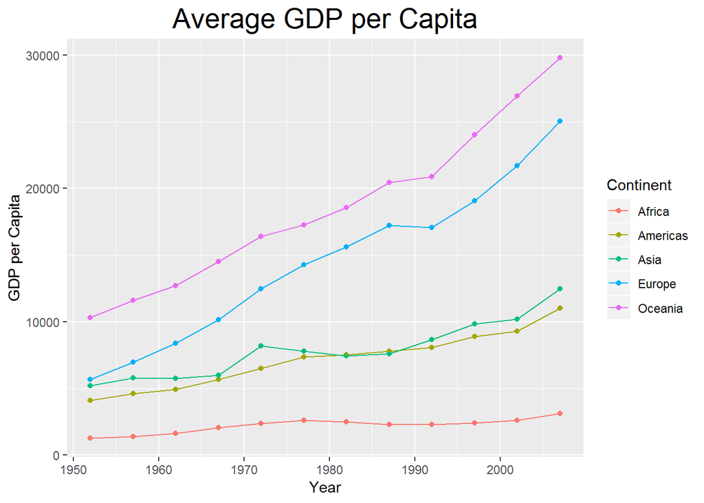

```r
gdp=tapply(gapminder$GDP.per.Capita,list(gapminder$Continent,gapminder$Year),mean)
gdp=data.frame(t(gdp))
Year=seq(from=1952,to=2007,by=5)
gdp=cbind(Year,gdp)
gdp=gather(data=gdp,Continent,GDP.per.Capita,-Year)
p3=ggplot(data=gdp,aes(x=Year,y=GDP.per.Capita,color=Continent))+
  geom_point()+
  geom_line()+
  ggtitle("Average GDP per Capita")+
  xlab("Year")+
  ylab("GDP per Capita")+
  theme(plot.title=element_text(size=20,hjust=0.5))
p3
```

### 4.1 GDP Per Capita for Every Countries in Americas

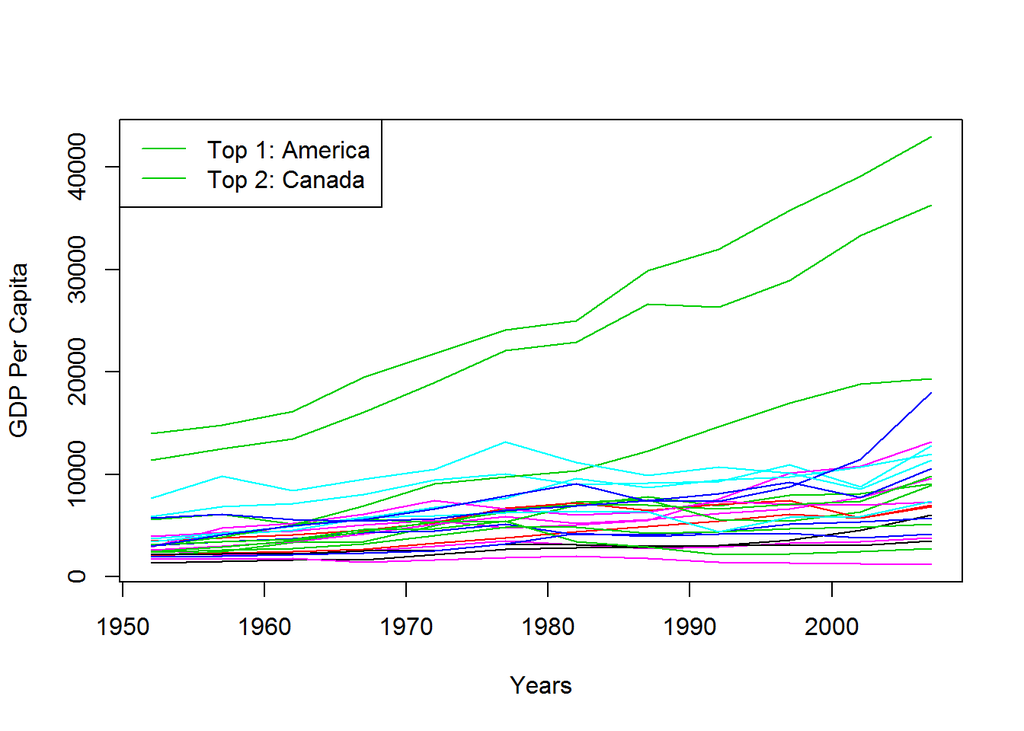

```r
gdp.Americas=gapminder%>%filter(Continent=="Americas")
gdp.Americas=tapply(gdp.Americas$GDP.per.Capita,list(gdp.Americas$Country,gdp.Americas$Year),mean)
gdp.Americas=t(data.frame(gdp.Americas))
row.names(gdp.Americas)=seq(1952,2007,5)
matplot(seq(1952,2007,5),gdp.Americas,type="l",lty=1,xlab="Years",ylab="GDP Per Capita")
legend("topleft",legend=c("Top 1: America","Top 2: Canada"),lty=1,col=3)
```

# (III) Interactive Web Application

- [Click me to reach the App](https://harrylu95.shinyapps.io/World_Facts/)

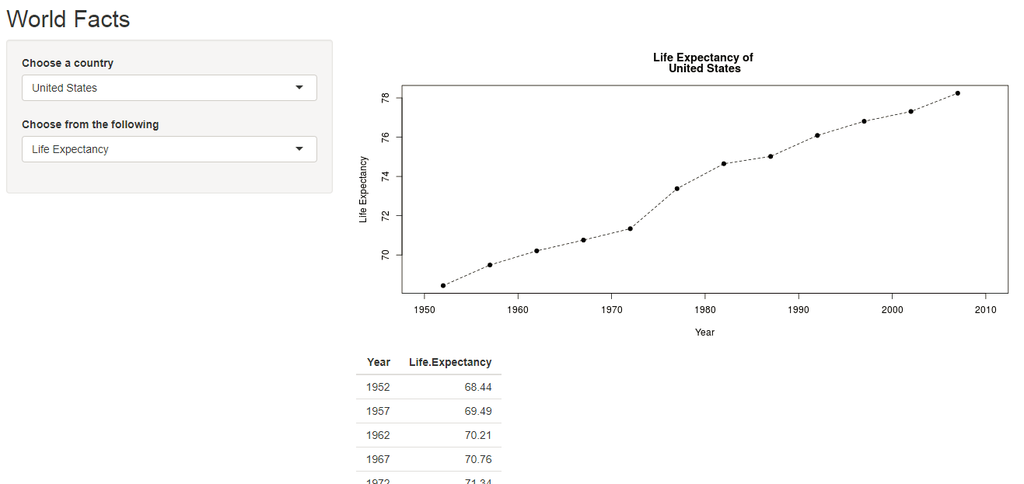

```r
library(shiny)
UI=fluidPage(
  titlePanel("World Facts"),
  sidebarLayout(
    sidebarPanel(
      selectInput(inputId="select",
                  label="Choose a country",
                  choices=unique(gapminder$Country)
      ),
      selectInput(inputId="object",
                  label="Choose from the following",
                  choices=c("Life Expectancy","Population","GDP per Capita")
      )
    ),
    mainPanel(plotOutput(outputId="figure"),
              tableOutput(outputId="data")
    )
  )
)

SERVER=function(input,output){
  f=function(temp){
    result=subset(gapminder,gapminder$Country==temp)
    return(result)
  }
  output$figure=renderPlot({
    country.name=reactive(input$select)
    dat=f(country.name())
    if (input$object=="Life Expectancy"){
      plot(dat$Life.Expectancy~dat$Year,xlim=c(1950,2010),xlab="Year",ylab="Life Expectancy",lty=2,type="l",main=c("Life Expectancy of ",country.name()))
      points(dat$Life.Expectancy~dat$Year,pch=19,col=1)
    }
    if (input$object=="Population"){
      plot(dat$Population~dat$Year,xlim=c(1950,2010),xlab="Year",ylab="Population",lty=2,type="l",main=c("Population of ",country.name()))
      points(dat$Population~dat$Year,pch=19,col=1)
    }
    if (input$object=="GDP per Capita"){
      plot(dat$GDP.per.Capita~dat$Year,xlim=c(1950,2010),xlab="Year",ylab="GDP per Capita",lty=2,type="l",main=c("GDP per Capita of ",country.name()))
      points(dat$GDP.per.Capita~dat$Year,pch=19,col=1)
    }
  })
  output$data=renderTable(colnames=T,{
    country.name=reactive(input$select)
    dat=f(country.name())
    if (input$object=="Life Expectancy"){
      temp=c()
      temp$Year=dat$Year
      temp$`Life Expectancy`=dat$Life.Expectancy
      return(temp)
    }
    if (input$object=="Population"){
      temp=c()
      temp$Year=dat$Year
      temp$Population=dat$Population
      return(temp)
    }
    if (input$object=="GDP per Capita"){
      temp=c()
      temp$Year=dat$Year
      temp$`GDP per Capita`=dat$GDP.per.Capita
      return(temp)
    }
  })
}

shinyApp(ui=UI,server=SERVER)
```